# Flight Delay Case

Author

Jamison Orton

Published

October 2, 2026

## R Packages

```r
library(tidyverse)
options(pillar.sigfig = 5)
```

## Q1

### Compute the mean, median, 90th percentile, and standard deviation of arrival delay minutes for RegionEx flights. Do the same for MDA flights.

```r
flightdf <- read.csv("flight_delay_clean.csv")

flightdf %>%
  filter(airline %in% c("RegionEx", "MDA")) %>%
  group_by(airline) %>%
  summarise(
    n = n(),
    mean_delay = round(mean(delay), 2),
    median_delay = round(median(delay), 2),
    perc_90 = round(as.numeric(quantile(delay, probs = 0.90)), 2),
    sd_delay = round(sd(delay), 2)
  )
```

```
# A tibble: 2 × 6
  airline      n mean_delay median_delay perc_90 sd_delay
  <chr>    <int>      <dbl>        <dbl>   <dbl>    <dbl>
1 MDA        120      10.9            13    16.1     6.34
2 RegionEx   240      15.66            9    21      27.65
```

### Contractual obligations aside, which measure of central tendency would be most appropriate for comparing airline performance?

Removing contractual obligation, using the median would most likely be the best measure of central tendency for comparing typical airline performance. RegionEx has a mean delay of 15.66 minutes but a median delay of only 9. This difference coupled with the high standard deviation of 27.65 shows that there are several large outliers skyrocketing the mean higher but that is not the “typical” flight experience. However, if the goal is to measure total passenger impact, the mean would be a more appropriate comparison because it reflects the influence of extreme delays.

## Q2

### Inspect the distribution of RegionEx’s arrival delays by constructing a histogram of the number of arrival delay minutes of RegionEx’s flights. Do the same for MDA’s flights. Hint: use facet_wrap().

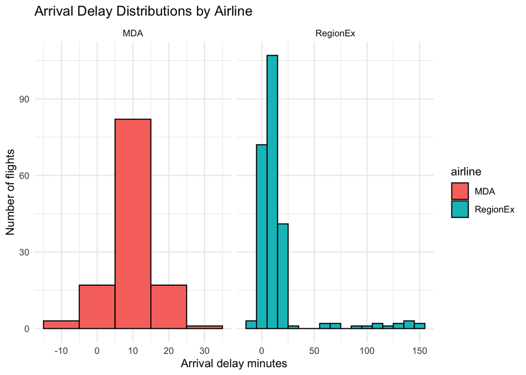

```r
flightdf %>%
  filter(airline %in% c("RegionEx", "MDA")) %>%
  ggplot(aes(x = delay)) +
  geom_histogram(
    aes(fill = airline),
    binwidth = 10,
    color = "black"
  ) +
  facet_wrap(~airline, scales = "free_x") +
  labs(
    title = "Arrival Delay Distributions by Airline",
    x = "Arrival delay minutes",
    y = "Number of flights"
  ) +
  theme_minimal()
```

## Q3

So far you have considered airline performance in terms of minutes delayed. However, the performance metrics, as noted in the case description, also include the percentage of delayed flights. Let’s verify that MDA’s COO is correct: does RegionEx have a higher percentage of delayed flights?

Here is code to answer that question:

### Create a summary table of percent delayed by airline.

```r
flightdf %>%
  group_by(airline) %>%
  summarize(n = n(), percent_delay = (mean(delay_indicator) * 100) %>% round(2))
```

```
# A tibble: 2 × 3
  airline      n percent_delay
  <chr>    <int>         <dbl>
1 MDA        120         25.83
2 RegionEx   240         26.25
```

Note that because delay_indicator is numeric (a binary 0/1 variable) calculating the mean of the vector returns the proportion of 1s, which, multiplied by 100, is equivalent to the percentage of delayed flights.

Write your own code to create a table summarizing the percentage of delayed flights by airline and route.

```r
flightdf %>%
  group_by(airline, route_code) %>%
  summarise(
    n = n(),
    percent_delay = round(mean(delay_indicator, na.rm = TRUE) * 100, 2),
    .groups = "drop"
  ) %>%
  arrange(route_code, airline)
```

```
# A tibble: 8 × 4
  airline  route_code     n percent_delay
  <chr>    <chr>      <int>         <dbl>
1 MDA      DFW/MSY       30         26.67
2 RegionEx DFW/MSY       90         25.56
3 MDA      MSY/DFW       30         30
4 RegionEx MSY/DFW       90         28.89
5 MDA      MSY/PNS       30         20
6 RegionEx MSY/PNS       30         20
7 MDA      PNS/MSY       30         26.67
8 RegionEx PNS/MSY       30         26.67
```

## Q4

### Compare the scheduled flight durations for the two airlines on each of their four routes. Also compare the actual flight durations for the two airlines. What do you notice? If the two airlines had the same scheduled duration, what impact would this have on their delay records?

```r
flightdf %>%
  group_by(route_code, airline) %>%
  summarise(
    scheduled_minutes = first(scheduled_flight_length),
    mean_actual_minutes = mean(actual_flight_length, na.rm = TRUE),
    mean_over_schedule = mean(
      actual_flight_length - scheduled_flight_length,
      na.rm = TRUE
    ),
    .groups = "drop"
  ) %>%
  arrange(route_code, airline)
```

```
# A tibble: 8 × 5
  route_code airline  scheduled_minutes mean_actual_minutes mean_over_schedule
  <chr>      <chr>                <int>               <dbl>              <dbl>
1 DFW/MSY    MDA                    100             113.47             13.467
2 DFW/MSY    RegionEx                90             106.42             16.422
3 MSY/DFW    MDA                    100             113.5              13.5
4 MSY/DFW    RegionEx                90             108.21             18.211
5 MSY/PNS    MDA                     75              85.2              10.2
6 MSY/PNS    RegionEx                70              81                11
7 PNS/MSY    MDA                     75              81.433             6.4333
8 PNS/MSY    RegionEx                70              80.4              10.4
```

RegionEx has shorter scheduled flight durations than MDA on each route. Because RegionEx allows less time in its schedule, the same actual flight duration or operational delay may result in a larger arrival delay relative to its schedule. If both airlines used the same scheduled durations, some of RegionEx’s recorded delays might be reduced or eliminated, making the airlines’ delay records more comparable.

## Q5

### Does the data support the claim that the on‐time performance of RegionEx is worse than that of MDA? Write a paragraph in which you argue a position. In your answer, please incorporate quantitative evidence from the earlier questions.

```r
mda_schedule <- flightdf %>%
  filter(airline == "MDA") %>%
  group_by(route_code) %>%
  summarise(
    mda_scheduled_minutes = first(scheduled_flight_length),
    .groups = "drop"
  )

flightdf %>%
  left_join(mda_schedule, by = "route_code") %>%
  filter(
    airline == "MDA" |
      (airline == "RegionEx" &
        actual_flight_length >= mda_scheduled_minutes)
  ) %>%
  group_by(airline) %>%
  summarise(
    mean_over_scheduled = round(
      mean(actual_flight_length - scheduled_flight_length, na.rm = TRUE),
      2
    ),
    n = n(),
    .groups = "drop"
  )
```

```
# A tibble: 2 × 3
  airline  mean_over_scheduled     n
  <chr>                  <dbl> <int>
1 MDA                    10.9    120
2 RegionEx               25.64   132
```

```r
regionex_schedule <- flightdf %>%
  filter(airline == "RegionEx") %>%
  group_by(route_code) %>%
  summarise(
    regionex_scheduled_minutes = first(scheduled_flight_length),
    .groups = "drop"
  )

flightdf %>%
  left_join(regionex_schedule, by = "route_code") %>%
  filter(
    airline == "RegionEx" |
      (airline == "MDA" &
        actual_flight_length >= regionex_scheduled_minutes)
  ) %>%
  group_by(airline) %>%
  summarise(
    mean_over_regionex_schedule = round(
      mean(actual_flight_length - regionex_scheduled_minutes, na.rm = TRUE),
      2
    ),
    n = n(),
    .groups = "drop"
  )
```

```
# A tibble: 2 × 3
  airline  mean_over_regionex_schedule     n
  <chr>                          <dbl> <int>
1 MDA                            18.8    118
2 RegionEx                       15.66   240
```